# Bayesian Regression Models with RStanARM

TJ Mahr  
Sept. 21, 2016

Madison R Users Group

[Github repository](https://github.com/tjmahr/MadR_RStanARM)  
[@tjmahr](https://twitter.com/tjmahr)

### Overview

- [How I got into Bayesian statistics](http://rpubs.com/tjmahr/rep-crisis)
- **[Some intuition-building about Bayes theorem](http://rpubs.com/tjmahr/bayes-theorem)**
- [Tour of RStanARM](http://rpubs.com/tjmahr/rstanarm-tour)
- [Where to learn more about Bayesian statistics](http://rpubs.com/tjmahr/bayes-learn-more)

## Building mathematical intuitions

### Caveat

- These slides and these examples are meant to illustrate the pieces of Bayes theorem.
- This is not a rigorous mathematical description of Bayesian probability or regression.

### Classifying emails

I got an email with the word “cialis” in it. Is it spam?

\[ P(\mathrm{spam} \mid \mathrm{cialis}) = \frac{ P(\mathrm{cialis} \mid \mathrm{spam}) \, P(\mathrm{spam})}{P(\mathrm{cialis})} \]

The two unconditional probabilities are base rates that need to be accounted for.

\[ P(\mathrm{spam} \mid \mathrm{cialis}) = \frac{\mathrm{cialis\ freq.\ in\ spam} \, * \mathrm{spam\ rate}}{\mathrm{cialis\ freq.}} \]

This example is just counting events. We can think more broadly about the probabilities.

I saw a creature, and it just *quacked* at me! Was it a duck?

\[ P(\mathrm{duck} \mid \mathrm{quacks}) = \frac{ P(\mathrm{quacks} \mid \mathrm{duck}) \, P(\mathrm{duck})}{P(\mathrm{quacks})} \]

- If it quacks like a duck…
- and after taking into account how common ducks are and how often animals quack…
- then it probably is a duck.

### General structure

How plausible is some hypothesis given the data?

\[ P(\mathrm{hypothesis} \mid \mathrm{data}) = \frac{ P(\mathrm{data} \mid \mathrm{hypothesis}) \, P(\mathrm{hypothesis})}{P(\mathrm{data})} \]

Pieces of the equation:

\[ \mathrm{posterior} = \frac{ \mathrm{likelihood} * \mathrm{prior}}{\mathrm{average\ likelihood}} \]

### Likelihood measures fit

We found some IQ scores in an old, questionable dataset.

```r
library(dplyr)
iqs <- car::Burt$IQbio
iqs
```

```
#>  [1]  82  80  88 108 116 117 132  71  75  93  95  88 111  63  77  86  83
#> [18]  93  97  87  94  96 112 113 106 107  98
```

IQs are designed to have a normal distribution with a population mean of 100 and an SD of 15.

How well do these data *fit* in that kind of bell curve?

### Density is a measure of relative likelihood

- Draw the data on a hypothetical bell curve with a mean of 100 and SD of 15.
- Height of each point on curve is density around that point.
- Higher density regions are more likely.
- Data farther from center is less likely.

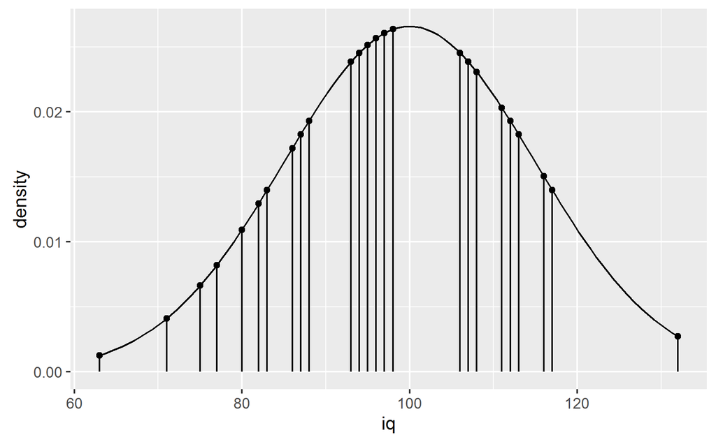

In comparison, the data are less likely in a bell curve with a mean of 130.

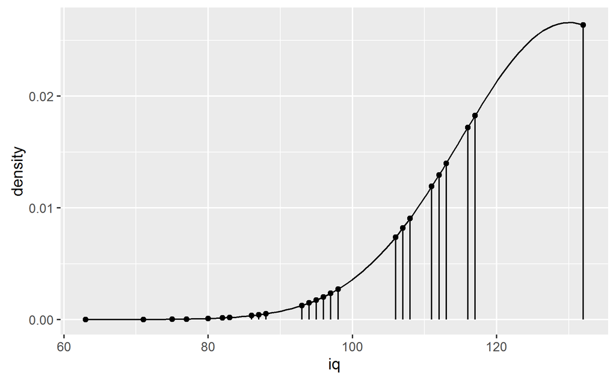

Density function `dnorm(xs, mean = 100, sd = 15)` tells us the height of each value in `xs` when drawn on a normal bell curve.

```r
# likelihood (density) of each point
dnorm(iqs, 100, 15) %>% round(3)
```

```
#>  [1] 0.013 0.011 0.019 0.023 0.015 0.014 0.003 0.004 0.007 0.024 0.025
#> [12] 0.019 0.020 0.001 0.008 0.017 0.014 0.024 0.026 0.018 0.025 0.026
#> [23] 0.019 0.018 0.025 0.024 0.026
```

Likelihood of all points is the product. These quantities get vanishingly small [so we sum their logs instead](https://math.stackexchange.com/questions/892832/why-we-consider-log-likelihood-instead-of-likelihood-in-gaussian-distribution). (Hence, *log-likelihoods*.)

```r
# vanishingly small!
prod(dnorm(iqs, 100, 15))
```

```
#> [1] 2.276823e-50
```

```r
# log scale
sum(dnorm(iqs, 100, 15, log = TRUE))
```

```
#> [1] -114.3065
```

Log-likelihoods provide a measure of how well the data fit a given normal distribution.

Which mean best fits the data? Below average IQ (85), average IQ (100), or above average IQ (115)?

```r
sum(dnorm(iqs, 85, 15, log = TRUE))
```

```
#> [1] -119.0065
```

```r
sum(dnorm(iqs, 100, 15, log = TRUE))
```

```
#> [1] -114.3065
```

```r
sum(dnorm(iqs, 115, 15, log = TRUE))
```

```
#> [1] -136.6065
```

The data fit best with the “population average” mean (100).

We just used a *maximum likelihood* criterion to choose among these alternatives!

### Likelihood summary

- We have some model of how the data could be generated. This model has tuneable parameters.
  - “The IQs are drawn from a normal distribution with an SD of 15 and some unknown mean.”
- Likelihood is how well the observed data fit in a particular data-generating model.
- Classical regression's “line of best fit” finds model parameters that maximize the likelihood of the data.

### Bayesian models

\[ \mathrm{posterior} = \frac{ \mathrm{likelihood} * \mathrm{prior}}{\mathrm{average\ likelihood}} \]

A Bayesian model examines a distribution over model parameters. What are all the plausible ways the data could have been generated?

- Prior: A probability distribution over model parameters.
- Update our prior information in proportion to how well the data fits with that information.

### Bayesian updating

Let's consider all integer values from 70 to 130 as equally probable means for the IQs. This is a uniform prior.

```r
# Keep track of last probability value
df_iq_model <- data_frame(
  mean = 70:130,
  prob = 1 / length(mean),
  previous = NA_real_)
sum(df_iq_model$prob)
```

```
#> [1] 1
```

```r
df_iq_model
```

```
#> # A tibble: 61 × 3
#>     mean       prob previous
#>    <int>      <dbl>    <dbl>
#> 1     70 0.01639344       NA
#> 2     71 0.01639344       NA
#> 3     72 0.01639344       NA
#> 4     73 0.01639344       NA
#> 5     74 0.01639344       NA
#> 6     75 0.01639344       NA
#> 7     76 0.01639344       NA
#> 8     77 0.01639344       NA
#> 9     78 0.01639344       NA
#> 10    79 0.01639344       NA
#> # ... with 51 more rows
```

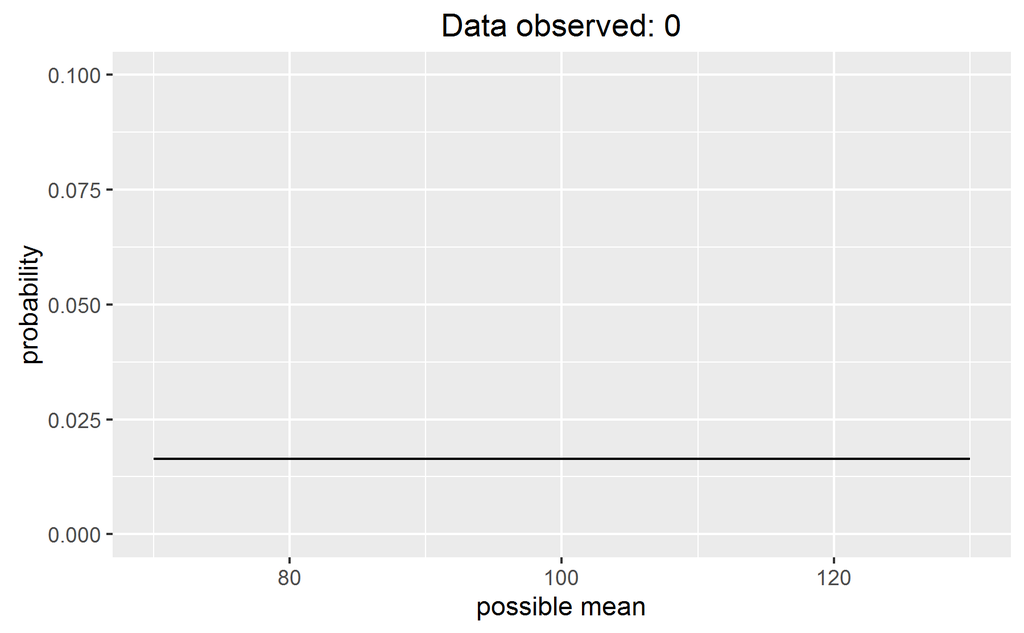

We observe one data-point and update our prior information using the likelihood of the data at each mean.

```r
df_iq_model$previous <- df_iq_model$prob
likelihoods <- dnorm(iqs[1], df_iq_model$mean, 15)
# numerator of bayes theorem
df_iq_model$prob <- likelihoods * df_iq_model$prob
sum(df_iq_model$prob)
```

```
#> [1] 0.01306729
```

That's not right. We need the *average likelihood* to ensure that the probabilities add up to 1. This is why it's sometimes called a *normalizing constant*.

```r
# include denominator of bayes theorem
df_iq_model$prob  <- df_iq_model$prob / sum(df_iq_model$prob)
sum(df_iq_model$prob)
```

```
#> [1] 1
```

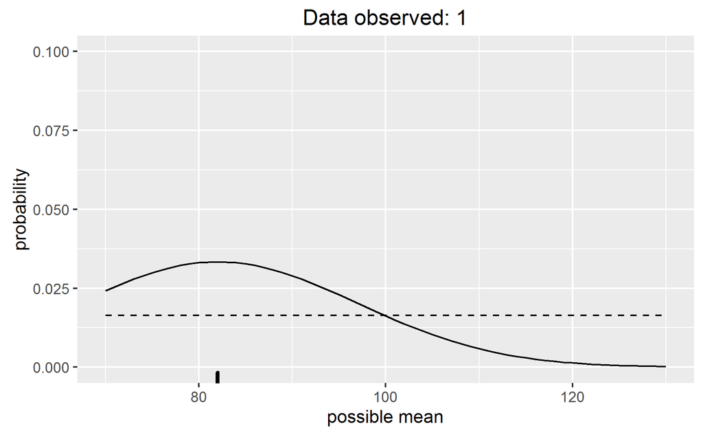

We observe another data-point and update the probability with the likelihood again.

```r
df_iq_model$previous <- df_iq_model$prob
likelihoods <- dnorm(iqs[2], df_iq_model$mean, 15)
df_iq_model$prob <- likelihoods * df_iq_model$prob
# normalize
df_iq_model$prob <- df_iq_model$prob / sum(df_iq_model$prob)
df_iq_model
```

```
#> # A tibble: 61 × 3
#>     mean       prob   previous
#>    <int>      <dbl>      <dbl>
#> 1     70 0.02551519 0.02422865
#> 2     71 0.02801128 0.02549920
#> 3     72 0.03047942 0.02671736
#> 4     73 0.03287154 0.02786958
#> 5     74 0.03513768 0.02894257
#> 6     75 0.03722765 0.02992359
#> 7     76 0.03909289 0.03080065
#> 8     77 0.04068830 0.03156283
#> 9     78 0.04197406 0.03220045
#> 10    79 0.04291726 0.03270526
#> # ... with 51 more rows
```

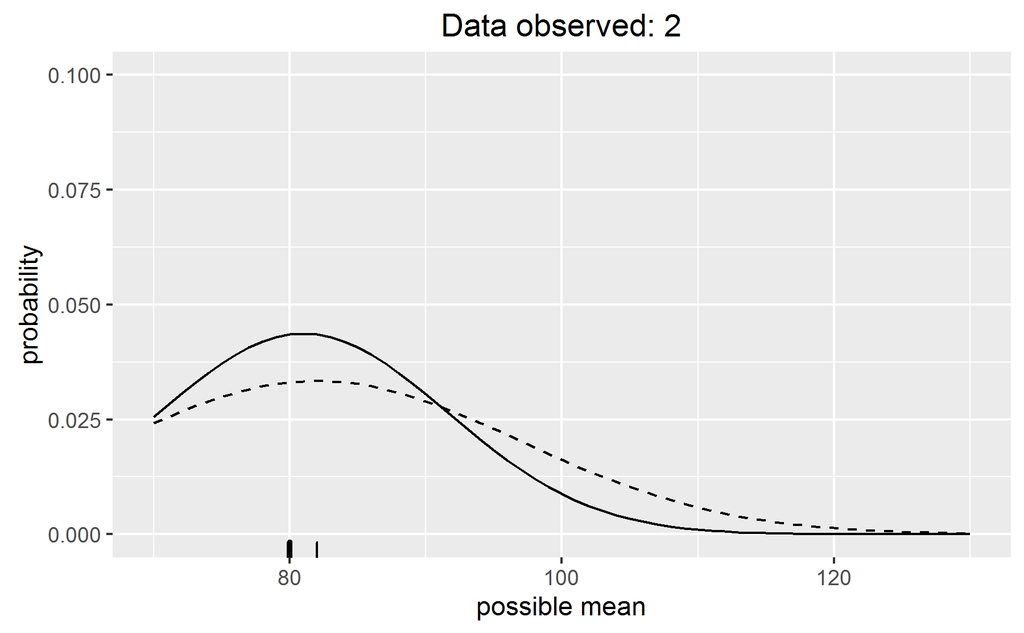

And one more…

```r
df_iq_model$previous <- df_iq_model$prob
likelihoods <- dnorm(iqs[3], df_iq_model$mean, 15)
df_iq_model$prob <- likelihoods * df_iq_model$prob
# normalize
df_iq_model$prob <- df_iq_model$prob / sum(df_iq_model$prob)
df_iq_model
```

```
#> # A tibble: 61 × 3
#>     mean       prob   previous
#>    <int>      <dbl>      <dbl>
#> 1     70 0.01490139 0.02551519
#> 2     71 0.01768232 0.02801128
#> 3     72 0.02070434 0.03047942
#> 4     73 0.02392174 0.03287154
#> 5     74 0.02727304 0.03513768
#> 6     75 0.03068201 0.03722765
#> 7     76 0.03405991 0.03909289
#> 8     77 0.03730890 0.04068830
#> 9     78 0.04032654 0.04197406
#> 10    79 0.04301093 0.04291726
#> # ... with 51 more rows
```

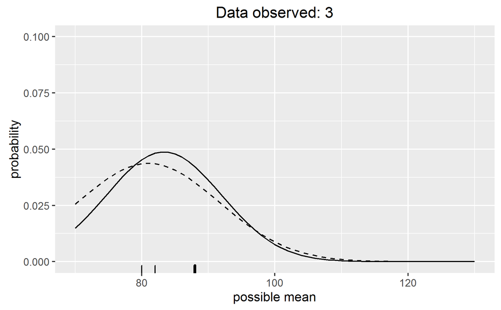

### Animation!

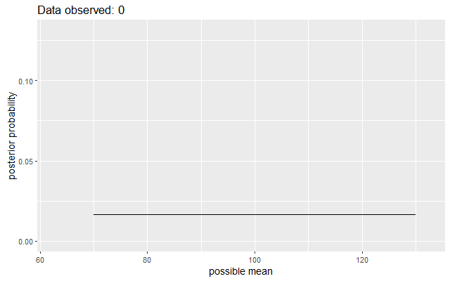

### Recap

- We have some model of how the data could be generated. This model has tuneable parameters.
- We have some prior distribution over plausible values for the parameters.
- Likelihood is how well the data fit in a model with a certain set of parameters.
- We explore all the plausible ways the data could be generated by the model and those parameters, and we update our prior information based on the fit of the data.
- We update our prior information based on the fit of the data.

### Basic regression model

We want to estimate a response \( y \) with 1 predictor \( x_1 \).

\[ \begin{align*} y_i &\sim \mathrm{Normal}(\mathrm{mean} = \mu_i, \mathrm{SD} = \sigma) \\ \mu_i &= \alpha + \beta_1*x_{1i} \end{align*} \]

Data generating model: Observation \( y_i \) is a draw from a normal distribution centered around a mean \( \mu_i \) with a standard deviation of \( \sigma \).

We estimate the mean with a constant “intercept” term \( \alpha \) plus a linear combination of predictor variables (just \( x_1 \) for now).

### Basically

For a model of weight predicted by height… but with continuous bell curves. A bell tunnel through the data.

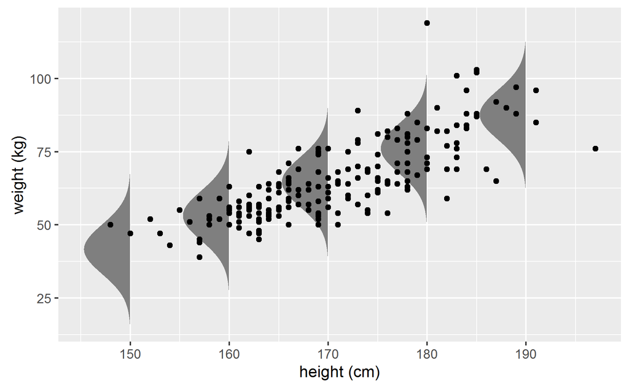

### Bayesian stats

Parameters we need to estimate for regression: \( \alpha, \beta_1, \sigma \)

- A classical model provides one model of many plausible models of the data. It'll find the parameters that maximize likelihood.
- A Bayesian model is a model of models. We get a *distribution of models* that are consistent with the data.

### This is where things get difficult

Parameters we need to estimate: \( \alpha, \beta_1, \sigma \)

\[ \mathrm{posterior} = \frac{ \mathrm{likelihood} * \mathrm{prior}}{\mathrm{average\ likelihood}} \]

\[ P(\alpha, \beta, \sigma \mid x) = \frac{ P(x \mid \alpha, \beta, \sigma) \, P(\alpha, \beta, \sigma)}{\iiint \, P(x \mid \alpha, \beta, \sigma) \, P(\alpha, \beta, \sigma) \,d\alpha \,d\beta \,d\sigma} \]

Things get gnarly. This is the black-box step.

We don't perform this integral calculus. Instead, we rely on Markov-chain Monte Carlo simulation to get us samples from the posterior. Those samples will provide a detailed picture of the posterior.

Enter Stan.

### Next

- [How I got into Bayesian statistics](http://rpubs.com/tjmahr/rep-crisis)
- [Some intuition-building about Bayes theorem](http://rpubs.com/tjmahr/bayes-theorem)
- **[Tour of RStanARM](http://rpubs.com/tjmahr/rstanarm-tour)**
- [Where to learn more about Bayesian statistics](http://rpubs.com/tjmahr/bayes-learn-more)